# SMI 2018 :: web scraping

6 de novembro de 2018

## parte I

- R e RStudio
- Web data e web scraping
- Coleta de dados na web
  - download
  - API
  - web scraping

## sugestões

- Repositório no github: web-scraping-smi2018
- IDE: [RStudio](https://www.rstudio.com/)
- Pacotes: [tidyverse](https://www.tidyverse.org/) | rvest | httr | xml2 | jsonlite | [DBI](https://db.rstudio.com/dbi/)
- Outros recursos:
  - [R for Data Science](https://r4ds.had.co.nz/)
  - [Happy Git and GitHub for the useR](http://happygitwithr.com/)
  - [rstudio::conf 2018](https://www.rstudio.com/resources/videos/rstudioconf-2018-talks/) | webinars | [cheat sheets](https://www.rstudio.com/resources/cheatsheets/)
  - [DataCamp](https://www.datacamp.com/) | [edX](https://www.edx.org/) | [Cousera](https://www.coursera.org/) | [Udacity](https://br.udacity.com/)
  - [Stackoverflow](https://stackoverflow.com/)

## Web Scraping

## web scraping

[figure not shown]

## web data

- Download
- APIs (Application Programming Interfaces)
- Web scraping
- Crawler

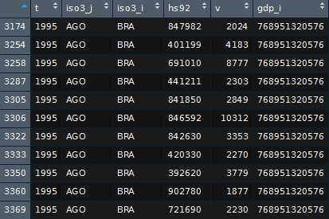

[figure not shown]

## web data

[figure not shown]

[figure not shown]

## Download

## download

### Tipos de arquivos

- csv (comma-separated values): `read.csv()`
- tsv (tab-separated values): `readr::read_tsv()`
- MS Excel (xls, xlsx): `readxl::read_excel()`
- zip: `unzip()`
- [JSON](https://json.org/example.html) (JavaScript Object Notation): `jsonlite::read_json()`
- [XML](https://www.w3.org/XML/) (Extensible Markup Language): `xml2::read_xml()`

## download

[figure not shown]

Portal Brasileiro de Dados Abertos: [dados.gov.br](http://dados.gov.br/dataset)  
Preços de comercialização de combustíveis: [anp.gov.br](http://www.anp.gov.br/precos-e-defesa/234-precos/levantamento-de-precos/868-serie-historica-do-levantamento-de-precos-e-de-margens-de-comercializacao-de-combustiveis)  
IPCA: ftp.ibge.gov.br

## APIs

## APIs

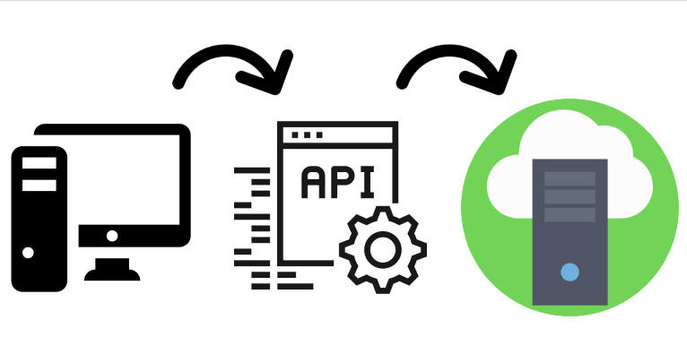

## APIs

[figure not shown]

## APIs

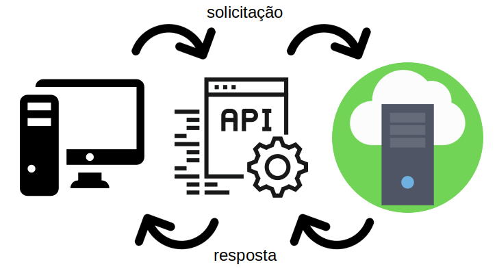

## APIs

### HTTP requests

- **GET**
- POST
- DELETE
- HEAD
- [outros](https://www.w3.org/Protocols/rfc2616/rfc2616-sec5.html)

## APIs

### Respostas

- **200**: sucesso!
- **300**: redirecionamento
- 400: erro de cliente
- 500: erro de servidor

[Códigos de resposta HTTP](https://www.w3.org/Protocols/rfc2616/rfc2616-sec10.html)

## APIs

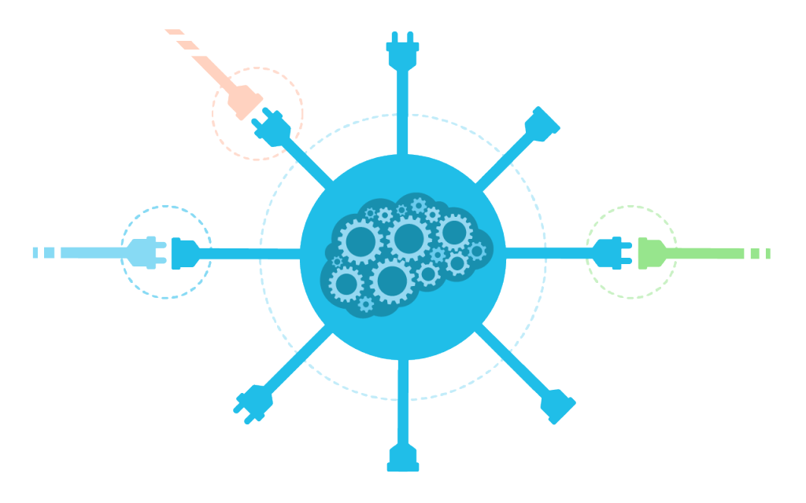

The Star Wars API: [swapi.co](https://swapi.co/) (pacote [rwars](https://cran.r-project.org/web/packages/rwars/index.html))  
Sistema IBGE de Recuperação Automática: [SIDRA](http://api.sidra.ibge.gov.br/)  
Banco Central do Brasil: [Portal de Dados Abertos](https://dadosabertos.bcb.gov.br/)

## Web Scraping

## web scraping

### Estrutura HTML ([tags](https://html.com/tags/))

- título: `<title> ... </title>`
- parágrafo de texto: `<p> ... </p>`
- blocos: `<div> ... </div>`
- tabela: `<table> ... </table>`
- hiperlink (âncora): `<a> ... </a>`

`<a href="http://www.ibge.gov.br/">IBGE</a>`

## web scraping

### Extrair com [`rvest`](https://www.rdocumentation.org/packages/rvest/versions/0.3.2/topics/html_text):

- `html_name()`
- `html_attr()`
- `html_text()`
- `html_table()`

`<a href="http://www.ibge.gov.br/">IBGE</a>`

## web scraping

[figure not shown]

Amazon: [amazon.com.br](https://www.amazon.com.br/)

## web scraping

### Selenium

- Selenium 2: [WebDriver](http://www.seleniumhq.org/projects/webdriver/)
- [Standalone server](http://selenium-release.storage.googleapis.com/index.html) ([v3.9.1](http://selenium-release.storage.googleapis.com/3.9/selenium-server-standalone-3.9.1.jar))
- Pacote RSelenium

### Executar o servidor

- Usando [Docker](http://ropensci.github.io/RSelenium/articles/docker.html)
- Usando `RSelenium::rsDriver()`
- Manualmente

## web scraping

### Funções [RSelenium](https://cran.r-project.org/web/packages/RSelenium/RSelenium.pdf):

- `navigate()`
- `goBack`
- `goForward()`
- `refresh()`
- `findElement()`
- `highlightElement()`
- `clickElement()`
- `mouseMoveToLocation()`
- `click()`
- `sendKeysToElement()`

## web scraping

[figure not shown]

GOL Linhas Aéreas: [voegol.com.br](https://voegol.com.br/pt)

## Boas práticas

## boas práticas

- Verificar e **respeitar** o [`robot.txt`](https://en.wikipedia.org/robots.txt).
- Identificação.
- Usar `httr::user_agent()` com e-mail de contato.
- Respeitar o limite de solicitações (rate-limiting).
- Se não houver limite explícito, usar o bom senso.
- Regra geral: intervalo de um segundo entre solicitações, usar `Sys.sleep(1)`.
- Priorizar horários de menor tráfego.

## Obrigado!

## obrigado

### **Augusto Fadel**

###### DPE/CEEC/GCAD

21 2142-0452  
augusto.fadel@ibge.gov.br  
augustofadel